# Lab 3

ECOL 620 - Applications in Landscape Ecology

George Woolsey

08 February, 2023

# Setup

```r
# bread-and-butter
library(tidyverse)
library(lubridate)
library(viridis)
library(scales)
library(latex2exp)
# visualization
library(ggrepel)
library(cowplot)
library(kableExtra)
# spatial analysis
library(USAboundaries)
library(sf)
library(terra)
library(spatstat) #for point pattern analyses
# set seed
set.seed(11)
```

# Rules

1. Using the provided R Markdown template, answer all questions and show your R code where necessary. Note, some questions are just plain text written answers.
2. Complete your assignment using the R markdown file and submit individual assignments to Canvas. Knit your script and submit an .html file on Canvas. Please use the following naming convention: lab3_firstname_lastname.html (ex. lab3_kyle_horton.html). Note, we will not grade labs in any other format.

# Question 1

Describe the biological use of Ripley’s K-function and L-function. Differentiate the differences between the two functions. (4 pts)

Ripley’s K-function and L-function are used to quantify the aggregation of points on a landscape within a circular radius from a given point. The resulting aggregation is then compared to a null model to determine if there is a significant difference between the observed pattern of points and a null model. The Complete Spatial Randomness (CSR) model is a commonly used null model. The CSR assumes that points are distributed over a study area in a completely random fashion where the probability of a point occurring at any given location is equal across the entire study area (i.e., the points come from a uniform distribution). If Ripley’s K-value or the L-value are significantly different from the CSR model, then there is evidence that the points are not distributed randomly on a landscape.

Ripley’s K-function quantifies the degree of spatial aggregation of points within a circular radius $r$ and then makes a comparison to what we would expect to see given a completely random process (i.e., CSR). As $r$ increases, the expected value of the K function under the CSR will increase exponentially because the area of a circle grows exponentially. The L-function takes the square root of Ripley’s K value to make the relationship between the resultant L-value $L(r)$ and the radius $r$ linear. The expected value of the L-function under the CSR follows a line with a slope of 1 and an intercept of 0 such that $L(r) = r$.

# Question 2

Describe the ecological meaning for the range of values produced by the L-function (i.e., L(r)-r) For instance, what does 0 mean, 1, or -1? (2 pts)

Using the L-function, the null hypothesis CSR follows a line with a slope of 1 and an intercept of 0 such that $L(r) = r$. Subtracting $r$ from the result produces $L(r) - r = 0$. Under these conditions, a value of $0$ indicates that the spatial arrangement of the points is completely random across the landscape, consistent with the CSR. When $L(r)-r > 0$, there is evidence for spatial aggregation of points, whereas if $L(r)-r < 0$ there is evidence for uniform (regular) distribution of points.

# Question 3

Why are edge effect correction factors necessary? (4 pts)

Edge effects occur in point pattern analysis near plot boundaries and arise due to missing data outside of the study area (e.g., spatial extent of the study). Edge effects due to arbitrary study area boundaries influence measurements and statistics by not considering the true, full range of data. Correction of edge effects is accomplished by weighting points or using buffers, for example. Edge effect correction methods that utilize weights consider the circumference of circular buffer around a given point that falls outside the spatial extent of the data and then weights each point within the radius proportionally (e.g., if 25% of circumference is *inside* the plot, the weight for points inside is $\frac{1}{0.25}=4$).

# Cactus data

## Question 4

Include a heat map (using ggplot) of the Ordway-Swisher Biological Station cactus data (e.g., Figure 4.4d). Use a smoothing parameter that best matches (Figure 4.4d). Visually, do the data appear randomly distributed? (4 pts)

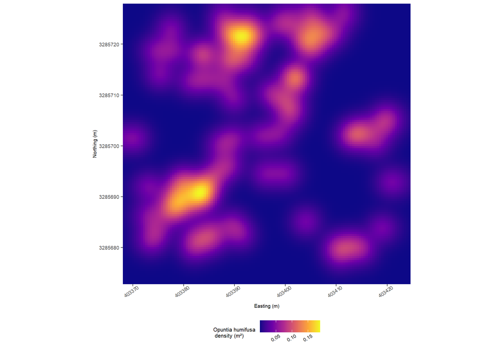

```r
# load data
cactus <- read.csv("../data/cactus.csv")
boundary <- read.csv("../data/cactus_boundaries.csv",header=T)
#create spatstat objects
ppp.window <- spatstat.geom::owin(
  xrange = c(boundary$Xmin, boundary$Xmax)
  , yrange = c(boundary$Ymin, boundary$Ymax)
)
ppp.cactus <- spatstat.geom::ppp(x = cactus$East, y = cactus$North, window = ppp.window)

#summary information
# summary(ppp.cactus) %>% glimpse()

# the average intensity that summary yields is lambda
lambda <- summary(ppp.cactus)$intensity

# calculate cactus density/intensity and convert to df
cactus_density_df <- ppp.cactus %>%
  stats::density(bw = 10) %>% # bw = the smoothing bandwidth (smoothing kernel)
  as.data.frame()

# plot heat map
ppp.cactus %>%
  stats::density(2) %>%
  as.data.frame() %>%
ggplot(data = .) +
  geom_tile(mapping = aes(x = x, y = y, fill = value)) +
  scale_x_continuous(expand = c(0, 0)) +
  scale_y_continuous(expand = c(0, 0)) +
  scale_fill_viridis_c(option = "plasma") +
  coord_fixed(ratio = 1) +
  labs(
    x = "Easting (m)"
    , y = "Northing (m)"
    , fill = "Opuntia humifusa \n density (m\u00b2)"
  ) +
  theme_bw() +
  theme(
    legend.position = "bottom"
    , legend.direction = "horizontal"
    , legend.text = element_text(size = 7, angle = 30, hjust = 0.7)
    , legend.title = element_text(size = 8)
    , axis.title = element_text(size = 7)
    , axis.text = element_text(size = 7)
    , axis.text.x = element_text(angle = 35, hjust = 0.7)
    , panel.border = element_blank()
  )
```

Based on the plot above of density of the eastern prickly pear (*Opuntia humifusa*) at the Ordway-Swisher Biological Station, it does not appear that this species is randomly distributed across the landscape. Visual inspection of the density plot seems to indicate that the intensity of points across the plot is distributed unevenly with some areas have higher density of points than other areas. This pattern seems to violate the assumption of a homogeneous point process.

## Question 5

What conclusion do you draw from the quadrat.test on ppp.cactus with a 4 by 4 quadrat of ? What are the shortcomings of this approach? (4 pts)

```r
#chi-sq test for complete spatial randomness, CSR
quadrat_test <- spatstat.core::quadrat.test(ppp.cactus
  , nx = 4, ny = 4, method = "Chisq", alternative = "two.sided"
)
quadrat_test
```

```
##
##  Chi-squared test of CSR using quadrat counts
##
## data:  ppp.cactus
## X2 = 35.463, df = 15, p-value = 0.004223
## alternative hypothesis: two.sided
##
## Quadrats: 4 by 4 grid of tiles
```

The `spatstat.core::quadrat.test` function performs a test of Complete Spatial Randomness (CSR) for a given point pattern, based on quadrat counts. The resulting $\chi^2$ test statistic is **35.46** with a p-value of **0.0042**. This test indicates that the point pattern observed in the eastern prickly pear data is significantly different from the null hypothesis of complete spatial randomness at the $\alpha = 0.05$ level. That is, the eastern prickly pear observation points are distributed non-randomly across the site. This approach does not consider edge effects and is a first-order metric that is based on point patterns across the entire study area.

## Question 6

When implementing the isotropic edge effect correction for the L-function for Ordway-Swisher Biological Station cactus data (Line 119), where do you see the greatest observed difference from the uncorrected L-function occur? Include both plots (uncorrected and corrected). Plot with ggplot. (5 pts)

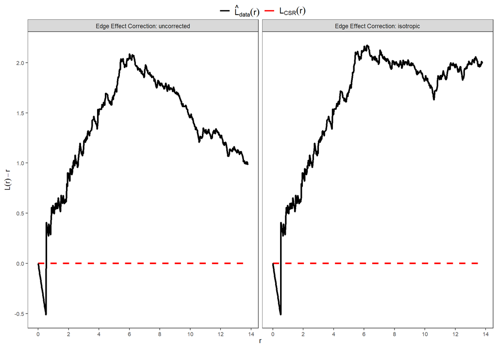

```r
# create data set of L-hat estimates
rbind(
  # L-function with no correction for edge effects
  spatstat.core::Lest(ppp.cactus, correction="none") %>%
    as.data.frame() %>%
    dplyr::rename(lhat = 3) %>%
    dplyr::mutate(corr = "Edge Effect Correction: uncorrected")
  # L-function with isotropic correction for edge effects
  , spatstat.core::Lest(ppp.cactus, correction="isotropic") %>%
    as.data.frame() %>%
    dplyr::rename(lhat = 3) %>%
    dplyr::mutate(corr = "Edge Effect Correction: isotropic")
  ) %>%
  dplyr::mutate(
    corr = ordered(corr, levels = c("Edge Effect Correction: uncorrected", "Edge Effect Correction: isotropic"))
  ) %>%
# plot with ggplot
  ggplot(data = ., mapping = aes(x = r)) +
    geom_line(mapping = aes(y = theo-r, color = "2"), size = 1.1, linetype = "dashed") +
    geom_line(mapping = aes(y = lhat-r, color = "1"), size = 1.1) +
    facet_wrap(.~corr, ) +
    scale_color_manual(
      values = c("black", "red")
      , labels = c(
        latex2exp::TeX("$\\hat{L}_{data}(r)$")
        , latex2exp::TeX("$\\L_{CSR}(r)$")
      )
    ) +
    scale_x_continuous(breaks = scales::breaks_extended(n = 8)) +
    scale_y_continuous(breaks = scales::breaks_extended(n = 8)) +
    labs(
      x = latex2exp::TeX("$r$")
      , y = latex2exp::TeX("$L(r)-r$")
    ) +
    theme_bw() +
    theme(
      legend.position = "top" # c(0.1, 0.9)
      , legend.text = element_text(size = 12, hjust = 0)
      , legend.title = element_blank()
      , legend.direction = "horizontal"
      , legend.margin = margin(0,0,-8,0)
      , axis.title = element_text(size = 10)
      , axis.text = element_text(size = 8)
      , panel.grid = element_blank()
    ) +
    guides(color = guide_legend(override.aes = list(size = 1)))
```

The greatest observed difference in the $\hat{L}_{data}(r)$ values between the uncorrected estimates and the estimates based on the isotropic correction for edge effects occur at higher values of $r$. As the radius ($r$) of the aggregation of points increases, the uncorrected $\hat{L}_{data}(r)$ values approach the values expected under complete spatial randomness but the edge effect correction reduces this bias as radius increases.

## Question 7

Using a point-wise envelope ($\alpha$ level of 0.05, isotropic correction), at what scales(s) do you reject the null hypothesis? In these regions, are the data clumped, randomly distributed, or uniform? No plot needed. (5 pts).

- The Fletcher text suggests that to get a 5% significance, we need `nsim` = 19. For a 1% significance, `nsim` = 99.
- The R documentation for the `spatstat.core::envelope` function, on the other hand, indicates that there is a relationship between `alpha`, `nrank`, and `nsim`, where: `alpha` = 2*`nrank`/(1 + `nsim`). If we replace `alpha` = 0.05 and `nrank` = 1 in this equation, we get `nsim` = 39. For `alpha` = 0.01 and `nrank` = 1, we get `nsim` = 199.

We will assume that the Fletcher text has a typo and stick to what’s in the function documentation.

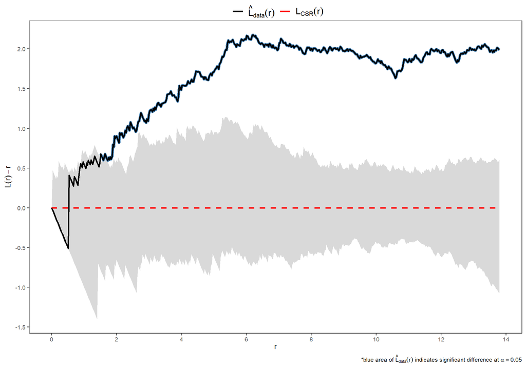

```r
set.seed(33)
#Monte Carlo simulations to calculate a global and pointwise confidence envelope under CSR
lest_env_iso <- spatstat.core::envelope(ppp.cactus
    , fun = Lest # pcf # = estimating the distance at which spatial patterns arise
    , nsim = 39
    , rank = 1
    , correction = "isotropic"
    , global = FALSE
  ) %>%
  as.data.frame() %>%
  dplyr::rename(lhat = obs) %>%
  dplyr::arrange(desc(r)) %>%
  dplyr::mutate(
    lhat_sig_diff = ifelse(lhat < lo | lhat > hi, lhat, as.numeric(NA))
    , is_lhat_sig_diff = ifelse(lhat < lo | lhat > hi, 1, 0)
    , cum = cumsum(is_lhat_sig_diff) * is_lhat_sig_diff
    , is_lhat_sig_diff_span = dplyr::case_when(
        is_lhat_sig_diff == 1
          & dplyr::lag(is_lhat_sig_diff, n = 1) == 1
          & dplyr::lead(is_lhat_sig_diff, n = 1) == 1
          & cumsum(is_lhat_sig_diff) * is_lhat_sig_diff > 5
          ~ 1
        , TRUE ~ 0
    )
  ) %>%
  dplyr::arrange(r)
# find range of r values for significant difference from CSR
min_sig <- lest_env_iso %>% dplyr::filter(is_lhat_sig_diff_span==1) %>% dplyr::pull(r) %>% min() %>% round(2)
max_sig <- lest_env_iso %>% dplyr::filter(is_lhat_sig_diff==1) %>% dplyr::pull(r) %>% max() %>% round(2)
# plot
  ggplot(data = lest_env_iso, mapping = aes(x = r)) +
    geom_ribbon(mapping = aes(ymin = lo-r, ymax = hi-r), fill = "gray85") +
    geom_line(mapping = aes(y = theo-r, color = "2"), size = 1, linetype = "dashed") +
    geom_line(mapping = aes(y = lhat_sig_diff-r), size = 1.9, color = "steelblue", show.legend = FALSE) +
    geom_line(mapping = aes(y = lhat-r, color = "1"), size = 1) +
    scale_color_manual(
      values = c("black", "red")
      , labels = c(
        latex2exp::TeX("$\\hat{L}_{data}(r)$")
        , latex2exp::TeX("$\\L_{CSR}(r)$")
      )
    ) +
    scale_x_continuous(breaks = scales::breaks_extended(n = 8)) +
    scale_y_continuous(breaks = scales::breaks_extended(n = 8)) +
    labs(
      x = latex2exp::TeX("$r$")
      , y = latex2exp::TeX("$L(r)-r$")
      , caption = latex2exp::TeX("*blue area of $\\hat{L}_{data}(r)$ indicates significant difference at $\\alpha = 0.05$")
    ) +
    theme_bw() +
    theme(
      legend.position = "top" # c(0.1, 0.9)
      , legend.text = element_text(size = 12, hjust = 0)
      , legend.title = element_blank()
      , legend.direction = "horizontal"
      , legend.margin = margin(0,0,-8,0)
      , axis.title = element_text(size = 10)
      , axis.text = element_text(size = 8)
      , panel.grid = element_blank()
      , plot.caption = element_text(size = 8)
    ) +
    guides(color = guide_legend(override.aes = list(size = 1)))
```

The figure above displays a point-wise envelope based on the L-function with a significance level of $\alpha = 0.05$ and an isotropic correction for edge effects. The null hypothesis of complete spatial randomness (CSR) can be rejected when the observed line falls outside the envelope for a given point aggregation radius ($r$). Based on this data, we reject the null hypothesis of a CSR point pattern in the spatial distribution of cactus at the site when the aggregation radius is between ~**1.54**m and **13.8**m. At this scale, the data indicates a non-random, aggregated point pattern.

# Ponderosa Pine data

## Question 8

Examining the Ponderosa pine data included within the spatstat package, how would you characterize the distribution of trees? Does your interpretation change across scale(s)? Use the envelope function to justify your conclusion. Include the point-wise confidence envelope plot using an $\alpha$ level of 0.01 and isotropic correction. Include the plot (produced in ggplot) of the tree locations and of the L-function with envelope (10 pts). (See example on Canvas)

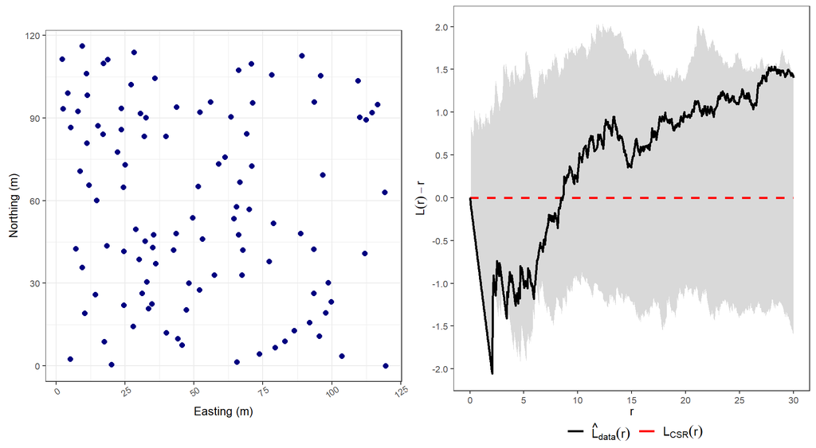

```r
set.seed(33)
# load data
# The dataset ponderosa is a spatial point pattern (object of class "ppp")
  # representing the point pattern of tree positions.
  # Spatial coordinates are given in metres.
spatstat.data::ponderosa %>% str()
# point pattern plot
plt_pts <- spatstat.data::ponderosa %>%
    as.data.frame() %>%
  ggplot(data = .) +
    geom_point(mapping = aes(x = x, y = y), color = "navy", size = 2) +
    coord_fixed(ratio = 1) +
    labs(
      x = "Easting (m)"
      , y = "Northing (m)"
    ) +
    theme_bw() +
    theme(
      axis.title = element_text(size = 10)
      , axis.text = element_text(size = 8)
      , axis.text.x = element_text(angle = 35, hjust = 0.7)
    )
# L-function plot with envelope
#Monte Carlo simulations to calculate a global and pointwise confidence envelope under CSR
plt_lfn <- spatstat.core::envelope(spatstat.data::ponderosa
    , fun = Lest # pcf # = estimating the distance at which spatial patterns arise
    , nsim = 199
    , rank = 1
    , correction = "isotropic"
    , global = FALSE
  ) %>%
  as.data.frame() %>%
  dplyr::rename(lhat = obs) %>%
  # plot
  ggplot(data = ., mapping = aes(x = r)) +
    geom_ribbon(mapping = aes(ymin = lo-r, ymax = hi-r), fill = "gray85") +
    geom_line(mapping = aes(y = theo-r, color = "2"), size = 1, linetype = "dashed") +
    geom_line(mapping = aes(y = lhat-r, color = "1"), size = 1) +
    scale_color_manual(
      values = c("black", "red")
      , labels = c(
        latex2exp::TeX("$\\hat{L}_{data}(r)$")
        , latex2exp::TeX("$\\L_{CSR}(r)$")
      )
    ) +
    scale_x_continuous(breaks = scales::breaks_extended(n = 8)) +
    scale_y_continuous(breaks = scales::breaks_extended(n = 8)) +
    labs(
      x = latex2exp::TeX("$r$")
      , y = latex2exp::TeX("$L(r)-r$")
    ) +
    theme_bw() +
    theme(
      legend.position = "bottom"
      , legend.text = element_text(size = 11, hjust = 0)
      , legend.title = element_blank()
      , legend.direction = "horizontal"
      , legend.margin = margin(-8,0,0,0)
      , axis.title = element_text(size = 10)
      , axis.text = element_text(size = 8)
      , panel.grid = element_blank()
    ) +
    guides(color = guide_legend(override.aes = list(size = 1)))
# combine plots
cowplot::plot_grid(
  plotlist =  list(plt_pts, plt_lfn)
  , nrow = 1
  , align = "hv"
)
```

Visual inspection of the point locations of the ponderosa pine (*Pinus ponderosa*) trees indicates a somewhat uniform (regular) distribution of trees. Over the entire extent of the study area, the distribution of trees does not appear to follow an aggregated spatial pattern. The point-wise envelope based on the L-function with a significance level of $\alpha = 0.01$ and an isotropic correction for edge effects supports this conclusion. The null hypothesis of complete spatial randomness (CSR) cannot be rejected across all spatial scales (with minor exceptions) as the observed line does not fall outside the envelope for a given point aggregation radius ($r$). Based on this data, we fail to reject the null hypothesis of a CSR point pattern in the spatial distribution of ponderosa pine at the site.

# Simulated data

## Question 9

Examine the spatial dispersion of three simulated point distributions (Poisson, uniform, and clustered). Include the point-wise confidence envelope plots at $\alpha$ level of 0.01 for the L-function with isotropic correction (using ggplot). In which distribution(s) do you see complete spatial randomness (CSR)? Include a 3 by 2 plot of the point locations and L-function with envelope (See example of Canvas) (10 pts).

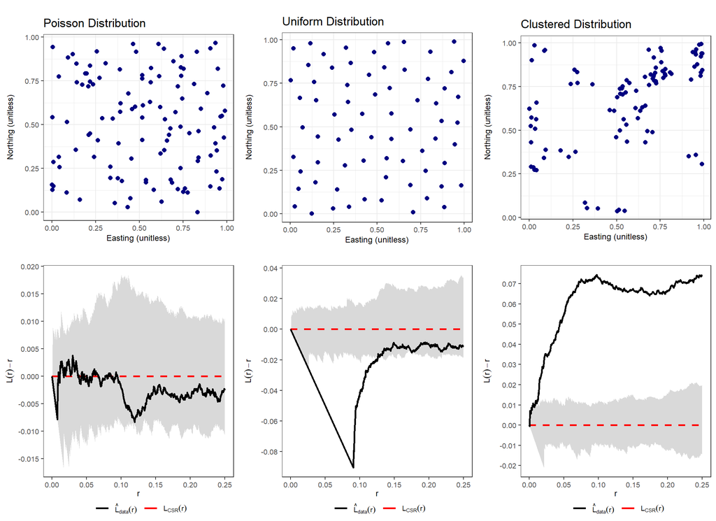

```r
set.seed(42)
# generate data
#poisson distribution
dist_pois <- spatstat.random::rpoispp(lambda = 100)
#uniform/regular distribution
dist_unif <- spatstat.random::rSSI(r = 0.09, n = 70)
#clustered distribution
dist_clust <- spatstat.random::rMatClust(kappa = 30, scale = 0.05, mu = 4)
# define function for point plot
plot_pnt_fn <- function(my_data, my_title){
  return(
  ggplot(data = my_data %>% as.data.frame()) +
    geom_point(mapping = aes(x = x, y = y), color = "navy", size = 2) +
    coord_fixed(ratio = 1) +
    labs(
      x = "Easting (unitless)"
      , y = "Northing (unitless)"
      , title = my_title
    ) +
    theme_bw() +
    theme(
      axis.title = element_text(size = 9)
      , axis.text = element_text(size = 8)
    )
  )
}
# define function for L-function with envelope plot
plot_lfnenv_fn <- function(my_data){
  return(
  spatstat.core::envelope(my_data
    , fun = Lest # pcf # = estimating the distance at which spatial patterns arise
    , nsim = 199
    , rank = 1
    , correction = "isotropic"
    , global = FALSE
  ) %>%
  as.data.frame() %>%
  dplyr::rename(lhat = obs) %>%
  # plot
  ggplot(data = ., mapping = aes(x = r)) +
    geom_ribbon(mapping = aes(ymin = lo-r, ymax = hi-r), fill = "gray85") +
    geom_line(mapping = aes(y = theo-r, color = "2"), size = 1, linetype = "dashed") +
    geom_line(mapping = aes(y = lhat-r, color = "1"), size = 1) +
    scale_color_manual(
      values = c("black", "red")
      , labels = c(
        latex2exp::TeX("$\\hat{L}_{data}(r)$")
        , latex2exp::TeX("$\\L_{CSR}(r)$")
      )
    ) +
    scale_x_continuous(breaks = scales::breaks_extended(n = 8)) +
    scale_y_continuous(breaks = scales::breaks_extended(n = 8)) +
    labs(
      x = latex2exp::TeX("$r$")
      , y = latex2exp::TeX("$L(r)-r$")
    ) +
    theme_bw() +
    theme(
      # legend.position = c(0.65, 0.08)
      legend.position = "bottom"
      , legend.text = element_text(size = 8, hjust = 0)
      , legend.title = element_blank()
      , legend.direction = "horizontal"
      , legend.margin = margin(-8,0,0,0)
      , axis.title = element_text(size = 9)
      , axis.text = element_text(size = 8)
      , panel.grid = element_blank()
    )
  )
}

cowplot::plot_grid(
  plot_pnt_fn(my_data = dist_pois, my_title = "Poisson Distribution")
  , plot_pnt_fn(my_data = dist_unif, my_title = "Uniform Distribution")
  , plot_pnt_fn(my_data = dist_clust, my_title = "Clustered Distribution")
  , plot_lfnenv_fn(my_data = dist_pois)
  , plot_lfnenv_fn(my_data = dist_unif)
  , plot_lfnenv_fn(my_data = dist_clust)
  , nrow = 2
  , align = "hv"
)
```

Using the L-function, subtracting $r$ from the result produces $L(r) - r = 0$ for the null hypothesis of complete spatial randomness (CSR). Based on the figure above, the sample points drawn from the Poisson distribution are most in-line with the CSR hypothesis of complete random point distribution across the landscape. There is evidence for uniform (regular) distribution of points for the sample points drawn from the uniform distribution as $L(r)-r < 0$ for $r$ values between 0 and ~0.125 (unitless); while points from the uniform distribution at larger scales are distributed more consistently with the CSR hypothesis. The clustered distribution is significantly different from the null hypothesis of CSR since over the range of $r$ scales $L(r)-r > 0$, suggesting that there is evidence for spatial aggregation of points.